# Part I - Prosper Loan Data

## by Estitxu Larralde Erasun

## Introduction

As per their website, Prosper is a peer-to-peer lending marketplace in the United States. It was founded in 2005.

The dataset includes 113 937 loans with 81 variables on each loan, including loan amount, interest rate, loan status and many more.

## Preliminary Wrangling

```python
# import all packages and set plots to be embedded inline
import numpy as np
import pandas as pd
import matplotlib.pyplot as plt
import seaborn as sb

%matplotlib inline
```

First I will load the prosper Loan dataset.

```python
loan= pd.read_csv('prosperLoanData.csv', engine='python')
```

I'll have a quick look of the structure and data type.

```python
print(loan.shape)
print(loan.dtypes)
print(loan.head(10))
```

```
(113937, 81)
ListingKey                              object
ListingNumber                            int64
ListingCreationDate                     object
CreditGrade                             object
Term                                     int64
LoanStatus                              object
ClosedDate                              object
BorrowerAPR                            float64
BorrowerRate                           float64
LenderYield                            float64
EstimatedEffectiveYield                float64
EstimatedLoss                          float64
EstimatedReturn                        float64
ProsperRating (numeric)                float64
ProsperRating (Alpha)                   object
ProsperScore                           float64
ListingCategory (numeric)                int64
BorrowerState                           object
Occupation                              object
EmploymentStatus                        object
EmploymentStatusDuration               float64
IsBorrowerHomeowner                       bool
CurrentlyInGroup                          bool
GroupKey                                object
DateCreditPulled                        object
CreditScoreRangeLower                  float64
CreditScoreRangeUpper                  float64
FirstRecordedCreditLine                 object
CurrentCreditLines                     float64
OpenCreditLines                        float64
                                        ...
TotalProsperLoans                      float64
TotalProsperPaymentsBilled             float64
OnTimeProsperPayments                  float64
ProsperPaymentsLessThanOneMonthLate    float64
ProsperPaymentsOneMonthPlusLate        float64
ProsperPrincipalBorrowed               float64
ProsperPrincipalOutstanding            float64
ScorexChangeAtTimeOfListing            float64
```

[output cut: 81 more lines]

```
9            1.0                0                          0

  InvestmentFromFriendsAmount Investors
0                         0.0       258
1                         0.0         1
2                         0.0        41
3                         0.0       158
4                         0.0        20
5                         0.0         1
6                         0.0         1
7                         0.0         1
8                         0.0         1
9                         0.0         1

[10 rows x 81 columns]
```

I look into the value counts of LoanStatus:

```python
loan['LoanStatus'].value_counts()
```

```
Current                   56576
Completed                 38074
Chargedoff                11992
Defaulted                  5018
Past Due (1-15 days)        806
Past Due (31-60 days)       363
Past Due (61-90 days)       313
Past Due (91-120 days)      304
Past Due (16-30 days)       265
FinalPaymentInProgress      205
Past Due (>120 days)         16
Cancelled                     5
Name: LoanStatus, dtype: int64
```

I'd like to find out the datatype of each variable as well as if there are null values.

```python
loan.info()
```

```
<class 'pandas.core.frame.DataFrame'>
RangeIndex: 113937 entries, 0 to 113936
Data columns (total 81 columns):
ListingKey                             113937 non-null object
ListingNumber                          113937 non-null int64
ListingCreationDate                    113937 non-null object
CreditGrade                            28953 non-null object
Term                                   113937 non-null int64
LoanStatus                             113937 non-null object
ClosedDate                             55089 non-null object
BorrowerAPR                            113912 non-null float64
BorrowerRate                           113937 non-null float64
LenderYield                            113937 non-null float64
EstimatedEffectiveYield                84853 non-null float64
EstimatedLoss                          84853 non-null float64
EstimatedReturn                        84853 non-null float64
ProsperRating (numeric)                84853 non-null float64
ProsperRating (Alpha)                  84853 non-null object
ProsperScore                           84853 non-null float64
ListingCategory (numeric)              113937 non-null int64
BorrowerState                          108422 non-null object
Occupation                             110349 non-null object
EmploymentStatus                       111682 non-null object
EmploymentStatusDuration               106312 non-null float64
IsBorrowerHomeowner                    113937 non-null bool
CurrentlyInGroup                       113937 non-null bool
GroupKey                               13341 non-null object
DateCreditPulled                       113937 non-null object
CreditScoreRangeLower                  113346 non-null float64
CreditScoreRangeUpper                  113346 non-null float64
FirstRecordedCreditLine                113240 non-null object
CurrentCreditLines                     106333 non-null float64
OpenCreditLines                        106333 non-null float64
TotalCreditLinespast7years             113240 non-null float64
OpenRevolvingAccounts                  113937 non-null int64
OpenRevolvingMonthlyPayment            113937 non-null float64
InquiriesLast6Months                   113240 non-null float64
TotalInquiries                         112778 non-null float64
CurrentDelinquencies                   113240 non-null float64
AmountDelinquent                       106315 non-null float64
```

[output cut: 31 more lines]

```
LP_CustomerPayments                    113937 non-null float64
LP_CustomerPrincipalPayments           113937 non-null float64
LP_InterestandFees                     113937 non-null float64
LP_ServiceFees                         113937 non-null float64
LP_CollectionFees                      113937 non-null float64
LP_GrossPrincipalLoss                  113937 non-null float64
LP_NetPrincipalLoss                    113937 non-null float64
LP_NonPrincipalRecoverypayments        113937 non-null float64
PercentFunded                          113937 non-null float64
Recommendations                        113937 non-null int64
InvestmentFromFriendsCount             113937 non-null int64
InvestmentFromFriendsAmount            113937 non-null float64
Investors                              113937 non-null int64
dtypes: bool(3), float64(50), int64(11), object(17)
memory usage: 68.1+ MB
```

For a simplicity purpose, I'm going to filter out the features I'm sure I won't be looking into.

First, I'll do a copy of the dataset to be sure I'm not modifying the original one.

```python
loan_1=loan.copy()
```

Then I filter only the features I'm interested in.

```python
loan_1=loan_1[['ListingNumber','ListingCreationDate','Term','LoanStatus', 'BorrowerAPR','EmploymentStatus','IsBorrowerHomeowner','RevolvingCreditBalance','StatedMonthlyIncome','LoanOriginalAmount','Investors']]
```

I look into the datatypes and the list of variables again:

```python
loan_1.info()
```

```
<class 'pandas.core.frame.DataFrame'>
RangeIndex: 113937 entries, 0 to 113936
Data columns (total 11 columns):
ListingNumber             113937 non-null int64
ListingCreationDate       113937 non-null object
Term                      113937 non-null int64
LoanStatus                113937 non-null object
BorrowerAPR               113912 non-null float64
EmploymentStatus          111682 non-null object
IsBorrowerHomeowner       113937 non-null bool
RevolvingCreditBalance    106333 non-null float64
StatedMonthlyIncome       113937 non-null float64
LoanOriginalAmount        113937 non-null int64
Investors                 113937 non-null int64
dtypes: bool(1), float64(3), int64(4), object(3)
memory usage: 8.8+ MB
```

```python
#Seing the first five rows helps me understand the structure of the data better
loan_1.head()
```

|  | ListingNumber | ListingCreationDate | Term | LoanStatus | BorrowerAPR | EmploymentStatus | IsBorrowerHomeowner | RevolvingCreditBalance | StatedMonthlyIncome | LoanOriginalAmount | Investors |
| --- | --- | --- | --- | --- | --- | --- | --- | --- | --- | --- | --- |
| 0 | 193129 | 2007-08-26 19:09:29.263000000 | 36 | Completed | 0.16516 | Self-employed | True | 0.0 | 3083.333333 | 9425 | 258 |
| 1 | 1209647 | 2014-02-27 08:28:07.900000000 | 36 | Current | 0.12016 | Employed | False | 3989.0 | 6125.000000 | 10000 | 1 |
| 2 | 81716 | 2007-01-05 15:00:47.090000000 | 36 | Completed | 0.28269 | Not available | False | NaN | 2083.333333 | 3001 | 41 |
| 3 | 658116 | 2012-10-22 11:02:35.010000000 | 36 | Current | 0.12528 | Employed | True | 1444.0 | 2875.000000 | 10000 | 158 |
| 4 | 909464 | 2013-09-14 18:38:39.097000000 | 36 | Current | 0.24614 | Employed | True | 6193.0 | 9583.333333 | 15000 | 20 |

I will drop loans with Current and Cancelled loan status. The reason is that for the Current status loans, we can't know whether they were paid off or not. For Cancelled status loans, they were never really created.

```python
#dropping 'Current' status
loan_1=loan_1[loan_1['LoanStatus']!='Current' ]
```

```python
#dropping 'Cancelled' status
loan_1=loan_1[loan_1['LoanStatus']!='Cancelled' ]
loan_1.head()
```

|  | ListingNumber | ListingCreationDate | Term | LoanStatus | BorrowerAPR | EmploymentStatus | IsBorrowerHomeowner | RevolvingCreditBalance | StatedMonthlyIncome | LoanOriginalAmount | Investors |
| --- | --- | --- | --- | --- | --- | --- | --- | --- | --- | --- | --- |
| 0 | 193129 | 2007-08-26 19:09:29.263000000 | 36 | Completed | 0.16516 | Self-employed | True | 0.0 | 3083.333333 | 9425 | 258 |
| 2 | 81716 | 2007-01-05 15:00:47.090000000 | 36 | Completed | 0.28269 | Not available | False | NaN | 2083.333333 | 3001 | 41 |
| 11 | 213551 | 2007-10-09 20:28:33.640000000 | 36 | Completed | 0.15033 | Full-time | False | 1220.0 | 1666.666667 | 1000 | 53 |
| 12 | 1081604 | 2013-12-15 20:01:10.757000000 | 36 | Past Due (1-15 days) | 0.17969 | Employed | False | 8624.0 | 2416.666667 | 4000 | 1 |
| 15 | 577164 | 2012-04-10 09:14:46.297000000 | 36 | Defaulted | 0.35797 | Other | True | 9103.0 | 5500.000000 | 4000 | 10 |

Now I will drop all the null values to tidy up the data.

```python
loan_1=loan_1.dropna()
```

```python
#Checking out there is no null value left in the data set
loan_1.isna().sum()
```

```
ListingNumber             0
ListingCreationDate       0
Term                      0
LoanStatus                0
BorrowerAPR               0
EmploymentStatus          0
IsBorrowerHomeowner       0
RevolvingCreditBalance    0
StatedMonthlyIncome       0
LoanOriginalAmount        0
Investors                 0
dtype: int64
```

I'm checking out again the format of the features so I can modify any that should have a different format:

```python
loan_1.reset_index(drop=True, inplace=True)
loan_1.info()
```

```
<class 'pandas.core.frame.DataFrame'>
RangeIndex: 49756 entries, 0 to 49755
Data columns (total 11 columns):
ListingNumber             49756 non-null int64
ListingCreationDate       49756 non-null object
Term                      49756 non-null int64
LoanStatus                49756 non-null object
BorrowerAPR               49756 non-null float64
EmploymentStatus          49756 non-null object
IsBorrowerHomeowner       49756 non-null bool
RevolvingCreditBalance    49756 non-null float64
StatedMonthlyIncome       49756 non-null float64
LoanOriginalAmount        49756 non-null int64
Investors                 49756 non-null int64
dtypes: bool(1), float64(3), int64(4), object(3)
memory usage: 3.8+ MB
```

I'm going to check if there are any duplicated rows:

```python
sum(loan_1.duplicated())
```

```
25
```

```python
#I drop the 25 duplicated rows
loan_1=loan_1.drop_duplicates()
```

```python
#I verify it worked
sum(loan_1.duplicated())
```

```
0
```

Some variables' data format isn't correct.

```python
# Modifying data format when necessary
loan_1.astype({'ListingNumber': 'str', 'RevolvingCreditBalance':'int', 'StatedMonthlyIncome':'int'}).dtypes
```

```
ListingNumber              object
ListingCreationDate        object
Term                        int64
LoanStatus                 object
BorrowerAPR               float64
EmploymentStatus           object
IsBorrowerHomeowner          bool
RevolvingCreditBalance      int64
StatedMonthlyIncome         int64
LoanOriginalAmount          int64
Investors                   int64
dtype: object
```

```python
loan_1['ListingCreationDate']=pd.to_datetime(loan_1['ListingCreationDate']).dt.floor('d')
```

I want to check the values of EmploymentStatus to see if I need to change the format or do any other modifications

```python
loan_1['EmploymentStatus'].value_counts()
```

```
Full-time        25037
Employed         18371
Self-employed     3047
Part-time         1064
Other              923
Retired            703
Not employed       586
Name: EmploymentStatus, dtype: int64
```

```python
loan_1=loan_1.replace(['Full-time','Self-employed','Part-time'], 'Employed')
```

```python
loan_1['EmploymentStatus'].value_counts()
```

```
Employed        47519
Other             923
Retired           703
Not employed      586
Name: EmploymentStatus, dtype: int64
```

I'm going to convert LoanStatus and EmploymentStatus variables into ordered categorical data type.

```python
# convert LoanStatus and EmploymentStatus into ordered categorical types
ordinal_var_dict = {'LoanStatus': ['Defaulted','Chargedoff','Past Due (>120 days)',
                                   'Past Due (91-120 days)','Past Due (61-90 days)',
                                   'Past Due (31-60 days)', 'Past Due (16-30 days)',
                                   'Past Due (1-15 days)', 'FinalPaymentInProgress',
                                   'Completed'], 'EmploymentStatus':['Other', 'Not employed','Retired','Employed']}

for var in ordinal_var_dict:
    ordered_var = pd.api.types.CategoricalDtype(ordered = True,
                                                categories = ordinal_var_dict[var])
    loan_1[var] = loan_1[var].astype(ordered_var)
```

```python
# Verifying data format
loan_1.info()
```

```
<class 'pandas.core.frame.DataFrame'>
Int64Index: 49731 entries, 0 to 49755
Data columns (total 11 columns):
ListingNumber             49731 non-null int64
ListingCreationDate       49731 non-null datetime64[ns]
Term                      49731 non-null int64
LoanStatus                49731 non-null category
BorrowerAPR               49731 non-null float64
EmploymentStatus          49731 non-null category
IsBorrowerHomeowner       49731 non-null bool
RevolvingCreditBalance    49731 non-null float64
StatedMonthlyIncome       49731 non-null float64
LoanOriginalAmount        49731 non-null int64
Investors                 49731 non-null int64
dtypes: bool(1), category(2), datetime64[ns](1), float64(3), int64(4)
memory usage: 3.6 MB
```

```python
loan_1.head()
```

|  | ListingNumber | ListingCreationDate | Term | LoanStatus | BorrowerAPR | EmploymentStatus | IsBorrowerHomeowner | RevolvingCreditBalance | StatedMonthlyIncome | LoanOriginalAmount | Investors |
| --- | --- | --- | --- | --- | --- | --- | --- | --- | --- | --- | --- |
| 0 | 193129 | 2007-08-26 | 36 | Completed | 0.16516 | Employed | True | 0.0 | 3083.333333 | 9425 | 258 |
| 1 | 213551 | 2007-10-09 | 36 | Completed | 0.15033 | Employed | False | 1220.0 | 1666.666667 | 1000 | 53 |
| 2 | 1081604 | 2013-12-15 | 36 | Past Due (1-15 days) | 0.17969 | Employed | False | 8624.0 | 2416.666667 | 4000 | 1 |
| 3 | 577164 | 2012-04-10 | 36 | Defaulted | 0.35797 | Other | True | 9103.0 | 5500.000000 | 4000 | 10 |
| 4 | 241498 | 2007-11-30 | 36 | Completed | 0.21488 | Employed | False | 134.0 | 3750.000000 | 3000 | 53 |

```python
loan_1.describe()
```

|  | ListingNumber | Term | BorrowerAPR | RevolvingCreditBalance | StatedMonthlyIncome | LoanOriginalAmount | Investors |
| --- | --- | --- | --- | --- | --- | --- | --- |
| count | 4.973100e+04 | 49731.000000 | 49731.000000 | 4.973100e+04 | 49731.000000 | 49731.000000 | 49731.000000 |
| mean | 4.332144e+05 | 37.380226 | 0.227615 | 1.569413e+04 | 5121.358385 | 6524.492590 | 109.045605 |
| std | 1.903016e+05 | 8.195928 | 0.089801 | 3.381603e+04 | 5695.314208 | 5269.590049 | 111.446228 |
| min | 9.827900e+04 | 12.000000 | 0.006530 | 0.000000e+00 | 0.000000 | 1000.000000 | 1.000000 |
| 25% | 2.896230e+05 | 36.000000 | 0.153240 | 1.643000e+03 | 2916.666667 | 3000.000000 | 33.000000 |
| 50% | 4.517730e+05 | 36.000000 | 0.222370 | 6.110000e+03 | 4250.000000 | 5000.000000 | 73.000000 |
| 75% | 5.487700e+05 | 36.000000 | 0.305130 | 1.619000e+04 | 6250.000000 | 8500.000000 | 148.000000 |
| max | 1.240719e+06 | 60.000000 | 0.423950 | 1.435667e+06 | 618547.833333 | 35000.000000 | 1189.000000 |

```python
loan_1.shape
```

```
(49731, 11)
```

### What is the structure of your dataset?

The dataset contains 113937 rows or loans and 81 columns or features.

After creating a copy of the dataset to prevent any modification of the original dataset, I filtered only the columns I was interested in for this analysis. Then I did some data wrangling to drop the null values, the duplicated rows and change the format of some columns. I also modified some values of the EmploymentStatus column to group any status that belonged into Employed.

After all the wrangling, there are 49731 observations (rows) and 11 features (columns)

### What is/are the main feature(s) of interest in your dataset?

I'm interested in the loan status and the BorrowerAPR (annual interest rate). I'd like to find out the correlation between the different variables and the result of the loan (is it successful or not? i.e. was it reimboursed?). Regarding the BorrowerAPR I'd like to see if there is correlation of some variables with obtaining a low interest rate.

LoanStatus column contains categorical data (format in the dataset is not correct): Completed, FinalPaymentInProgress, Past Due (1-15 days), Past Due (16-30 days), Past Due (31-60 days), Past Due (61-90 days), Past Due (91-120 days), Past Due (>120 days), Chargedoff, Defaulted.

As Cancelled loans have never been created, they can be dropped, as well as Current status loans, because we don't know the outcome.

BorrowerAPR is a float number (float data type) representing the interest rate obtained by the borrower for their loan.

### What features in the dataset do you think will help support your investigation into your feature(s) of interest?

I think the 'stated monthly income', the 'employment status' and the 'revolving credit balance' could have some correlation with the status of the loans.

I would like to measure also the features that seem to weigh on the APR of the borrower of each loan. I think similar features as the ones mentioned just above could have some correlation with the obtained APR. On the other hand, other features as Term (usually loans with fewer instalments get a lower interest rate) could have some influence, too.

## Univariate Exploration

First, I will have a look into the distribution of LoanStatus

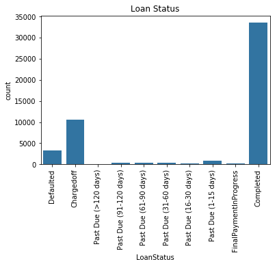

```python
base_color= sb.color_palette()[0]
sb.countplot(data=loan_1, x='LoanStatus', color=base_color)
plt.title('Loan Status')
plt.xticks(rotation=90);
```

Not surprisingly, the majority of the loans are completed. Nevertheless, the summed amount of Defaulted and Chargedoff loans is about 15000, i.e. over 40% of the amount of succesfully completed loans, which means that the risk of not being reimboursed by the borrowers is quite high.

Most of loans with past-due payments fall into the category of the shortest delay (1-15 days, 800 observations).

I used value_counts method below to get the exact figures.

```python
loan_1['LoanStatus'].value_counts()
```

```
Completed                 33544
Chargedoff                10636
Defaulted                  3291
Past Due (1-15 days)        800
Past Due (31-60 days)       361
Past Due (61-90 days)       311
Past Due (91-120 days)      304
Past Due (16-30 days)       265
FinalPaymentInProgress      203
Past Due (>120 days)         16
Name: LoanStatus, dtype: int64
```

Now I'll look into the distribution of 'BorrowerAPR' variable to find out the range of annual interest rate obtained for the loans in the sample

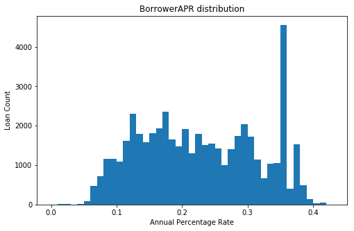

```python
binsize = 0.01
bins = np.arange(0, loan_1['BorrowerAPR'].max()+binsize, binsize)

plt.figure(figsize=[8, 5])
plt.hist(data = loan_1, x = 'BorrowerAPR', bins = bins)
plt.xlabel('Annual Percentage Rate')
plt.ylabel('Loan Count')
plt.title ('BorrowerAPR distribution')
plt.show()
```

The plot shows a multimodal distribution, with a high peak at 0.355/0.36 interest rate.

I'm going to focus on the APR between 0.35 and 0.37 to see where exactly is the peak.

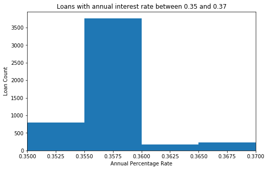

```python
binsize = 0.005
bins = np.arange(0, loan_1['BorrowerAPR'].max()+binsize, binsize)

plt.figure(figsize=[8, 5])
plt.hist(data = loan_1, x = 'BorrowerAPR', bins = bins)
plt.xlabel('Annual Percentage Rate')
plt.ylabel('Loan Count')
plt.xlim(0.35,0.37)
plt.title('Loans with annual interest rate between 0.35 and 0.37')
plt.show()
```

The most frequent BorrowerAPR is between 0.355 and 0.36

I'd like to know how the number of listings or loans evolved over the months. I think that as the regulation changed from July 2009 onwards, it could be interesting to see if the number of loans fell significantly from that date on.

```python
#First, I will create a column with only the year and the month of each loan.
loan_1['ListingCreationMonth']=loan_1['ListingCreationDate'].dt.to_period('M')
```

```python
loan_date=loan_1.sort_values(by='ListingCreationMonth', ascending=True)
```

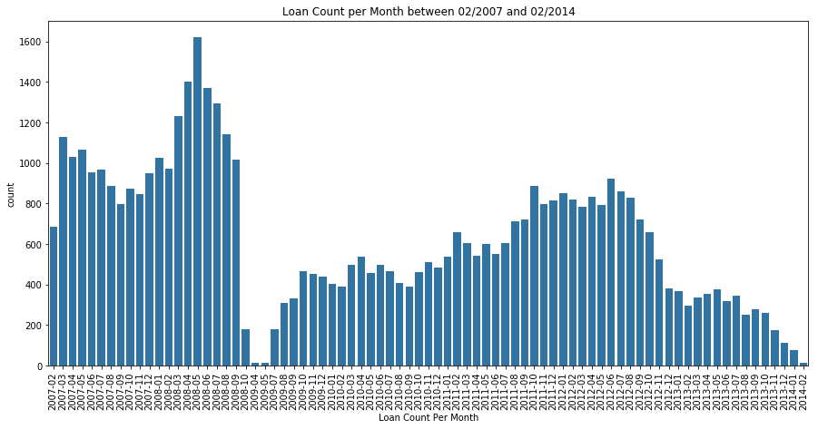

```python
plt.figure(figsize=[15, 7])
base_color= sb.color_palette()[0]
sb.countplot(data=loan_date, x='ListingCreationMonth', color=base_color)
plt.xticks(rotation=90);
plt.xlabel('Loan Count Per Month')
plt.title('Loan Count per Month between 02/2007 and 02/2014')
plt.show();
```

As we can observe there is a deep decrease of loan count in october 2008 and no loans at all from November 2008 to March 2009. After looking it up, I found the reason at the website of the Securities and Exchanges Commission:

### In the Matter of Prosper Marketplace, Inc.

*On November 24, the Commission issued an Order Instituting Administrative Proceedings Pursuant to Section 8A of the Securities Act of 1933, Making Findings and Imposing a Cease and Desist Order (Order) against Prosper Marketplace, Inc. (Prosper). The Order finds that Prosper violated Sections 5(a) and (c) of the Securities Act of 1933 during the period January 1, 2006 through October 14, 2008, by engaging in the unregistered offering of securities via Prosper's online lending platform. Prosper offers loans in a double-blind, auction-like process wherein multiple lenders bid to fund loans to borrowers. Since the inception of its platform in January 2006, Prosper has initiated approximately $174 million in loans.*

Source: https://www.sec.gov/news/digest/2008/dig112408.htm

End of April 2009 the California Department of Corporations gave the go-ahead to operate again to Prosper but activity slowed down quite a bit due to stricter rules for borrowers:

*Prosper*'*s relaunched version will have slightly new rules. Borrowers will have to have credit scores above 640 to request a loan now, for example.*

Source: https://money.cnn.com/2009/04/28/technology/hempel_prosper.fortune/?section=money_technology

Now I'll have a look into the distribution of the variable 'IsBorrowerHomeowner':

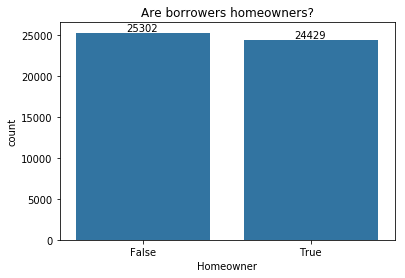

```python
base_color= sb.color_palette()[0]

ax=sb.countplot(data=loan_1, x='IsBorrowerHomeowner', color=base_color);
for p in ax.patches:
    ax.annotate((p.get_height()), (p.get_x()+0.3, p.get_height()+150));

plt.xlabel('Homeowner')
plt.title('Are borrowers homeowners?');
```

As we can observe above the number of homeowners among the borrowers and those that are not are very similar

I want to find out the distribution of the loans per duration (Term). I saw that the shortest is 12 months long and the longest 60 months long, i.e. 1 to 5 years loans.

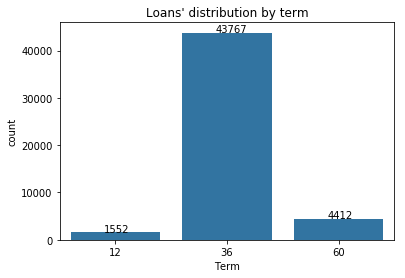

```python
base_color= sb.color_palette()[0]
ax=sb.countplot(data=loan_1, x='Term', color=base_color);
for p in ax.patches:
        ax.annotate((p.get_height()), (p.get_x()+0.3, p.get_height()+150));
plt.xlabel('Term')
plt.title('Loans\' distribution by term');
```

The big majority of loans in the sample were contracted for 36 months.

I'd like to find out the EmploymentStatus values distribution for our data sample.

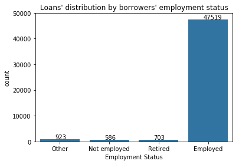

```python
base_color= sb.color_palette()[0]
ax=sb.countplot(data=loan_1, x='EmploymentStatus', color=base_color)
for p in ax.patches:
        ax.annotate((p.get_height()), (p.get_x()+0.3, p.get_height()+150));
plt.xlabel('Employment Status')
plt.title('Loans\' distribution by borrowers\' employment status');
```

The big majority of the borrowers are Employed (47500 out of 49000 observations).

#### Revolving Credit Balance

Banks and other financial institutions consider a positive revolving credit balance of a customer as a negative factor when contracting a new loan.

I'm interested in finding out the correlation between RevolvingCreditBalance variable and LoanStatus and Borrower APR. But first, I'd like to see the distribution of the RevolvingCreditBalance

The maximum value of RevolvingCredit Balance is of 1.5M USD:

```python
print(loan_1['RevolvingCreditBalance'].max())
```

```
1435667.0
```

Therefore I applied a limit to the x values to be able to visualize the plot because high outliers are very extreme.

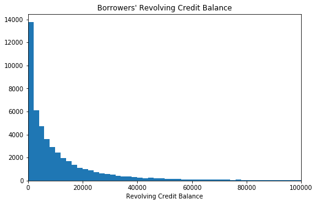

```python
bins= np.arange(min(loan_1['RevolvingCreditBalance']), max(loan_1['RevolvingCreditBalance'])+2000, 2000)
plt.figure(figsize=[8, 5])
plt.hist(data = loan_1, x = 'RevolvingCreditBalance', bins=bins)
plt.xlim(0, 100000)
plt.xlabel('Revolving Credit Balance')
plt.title('Borrowers\' Revolving Credit Balance')
plt.show();
```

The distribution of the Revolving Credit Balance is still very right skewed. I'm going to try a log scale.

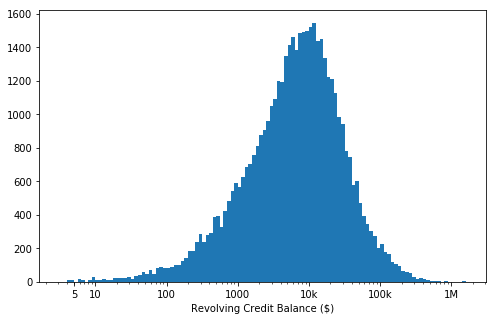

```python
log_binsize = 0.05
bins = 10 ** np.arange(0.5, np.log10(loan_1['RevolvingCreditBalance'].max())+log_binsize, log_binsize)
plt.figure(figsize=[8, 5])
plt.hist(data = loan_1, x = 'RevolvingCreditBalance', bins=bins)
plt.xscale('log')
plt.xticks([5, 1e1, 1e2, 1e3, 1e4, 1e5,1e6], [5, '10', '100', '1000', '10k', '100k', '1M'])
plt.xlabel('Revolving Credit Balance ($)')
plt.show();
```

Now the distribution looks quite symmetrical and normal, slightly skewed to the left. The peak is around 10K dollars of Revolving Credit Balance. There are more observations to the left (below 1000 dollars) than to the right (above 100K dollars).

Now I'm going to look into StatedMonthlyIncome by the borrowers.

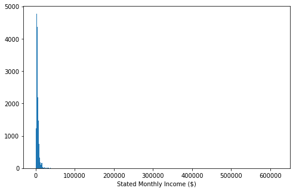

```python
binsize = 500
bins = np.arange(0, loan_1['StatedMonthlyIncome'].max()+binsize, binsize)

plt.figure(figsize=[8, 5])
plt.hist(data = loan_1, x = 'StatedMonthlyIncome', bins = bins)
plt.xlabel('Stated Monthly Income ($)')
plt.show()
```

There seem to be very extreme values for the variable StatedMonthlyIncome. I'm going to deepen my analysis to see how many observations there are with a higher montly income than 50000 dollars and see if I need to filter them out

```python
high_income = loan_1['StatedMonthlyIncome'] >50000

print(high_income.sum())
print(loan_1.loc[high_income,:])
```

```
33
       ListingNumber ListingCreationDate  Term  LoanStatus  BorrowerAPR  \
2038          627856          2012-08-22    36   Completed      0.12528
3515          500651          2011-04-02    36   Completed      0.35643
4927          110548          2007-03-13    36   Completed      0.08684
6712          368705          2008-07-16    36   Completed      0.18268
6904          197399          2007-09-04    36   Defaulted      0.21739
7582          501462          2011-04-08    36   Completed      0.35643
9009          660613          2012-10-25    36   Completed      0.24758
9246          524563          2011-08-30    36   Completed      0.16056
11081         120510          2007-04-07    36   Completed      0.20614
11786         535197          2011-10-24    36   Completed      0.20200
12861         651533          2012-10-09    12   Completed      0.17493
15379         461028          2010-06-01    36   Completed      0.07389
19984         155742          2007-06-21    36   Completed      0.09688
```

[output cut: 90 more lines]

There are 33 rows with a StatedMonthlyIncome superior to 50000USD per month.

I'm going to check two columns that I left out of our sample to see if the values are coherent with those of the StatedMonthlyIncome variable.

```python
loan['IncomeVerifiable'].value_counts()
```

```
True     105268
False      8669
Name: IncomeVerifiable, dtype: int64
```

```python
loan_2=loan[loan['StatedMonthlyIncome']>50000]
loan_2['IncomeVerifiable'].value_counts()
```

```
True     60
False    23
Name: IncomeVerifiable, dtype: int64
```

```python
loan['IncomeRange'].value_counts()
```

```
$25,000-49,999    32192
$50,000-74,999    31050
$100,000+         17337
$75,000-99,999    16916
Not displayed      7741
$1-24,999          7274
Not employed        806
$0                  621
Name: IncomeRange, dtype: int64
```

```python
loan_2['IncomeRange'].value_counts()
```

```
$100,000+         73
Not displayed      8
$50,000-74,999     1
$75,000-99,999     1
Name: IncomeRange, dtype: int64
```

The IncomeRange and IncomeVerifiable seem coherent with the highest values of StatedMonthlyIncome. I still have doubts of the veracity of the values as these seem to be revenues that the borrowers stated to have(it is not clear if they were verified). Also I'm wondering if some borrowers could have stated annual values instead of monthly ones as requested by the feature.

Nevertheless, I'm going to narrow the focus of the visualisation for StatedMonthlyIncome to have a better understanding of the data distribution.

First I will create a function to find the 99th percentile of a variable:

```python
def percentile(var):
    loan_describe=loan_1[var].describe([.25,.75,.9,.95,.99])
    return loan_describe.loc["99%"]
```

```python
Stated=['StatedMonthlyIncome']
percentile99=percentile(Stated)
percentile99
```

```
StatedMonthlyIncome    18750.0
Name: 99%, dtype: float64
```

As we can see rows where StatedMonthlyIncome is over 18750 dollars represent the 1% of the data sample.

Now I will visualize all the values but the last 1% percentile for StatedMonthlyIncome

```python
loan_select=loan_1[loan_1['StatedMonthlyIncome']<=percentile99[0]]
```

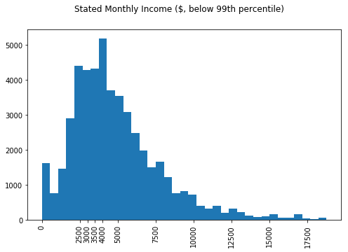

```python
plt.figure(figsize=[8, 5])
plt.hist(data =loan_select , x = 'StatedMonthlyIncome', bins = 35)
plt.xticks([0, 2500, 3000, 3500, 4000, 5000, 7500, 10000, 12500, 15000, 17500], [0, 2500, 3000, 3500, 4000, 5000, 7500, 10000, 12500, 15000, 17500], rotation=90)
plt.suptitle("Stated Monthly Income ($, below 99th percentile)");
```

The data sample distribution is still skewed to the right. Nevertheless we can now observe that most of the stated monthly income is in the range of 2000-7500 USD. Most important peak is around 4000 USD per month.

Now I'm going to look into the last two variables' distribution.

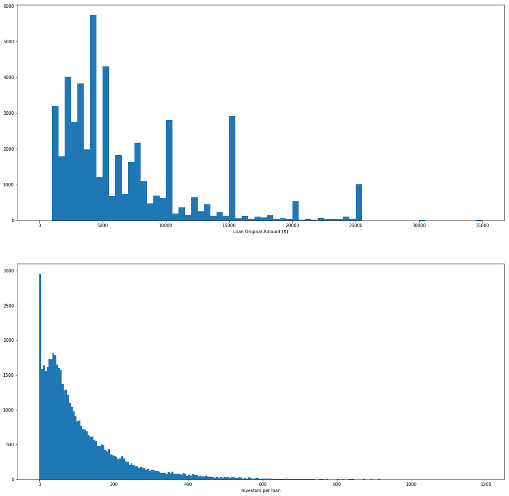

```python
plt.figure(figsize = [20, 20])

# histogram on top
plt.subplot(2, 1, 1)
bins1 = np.arange(0, loan_1['LoanOriginalAmount'].max()+500, 500)
plt.hist(data = loan_1, x = 'LoanOriginalAmount', bins = bins1);
plt.xlabel('Loan Original Amount ($)')

# histogram on bottom
plt.subplot(2, 1, 2) # 2 rows, 1 col, subplot 2
bins2= np.arange(0, loan_1['Investors'].max()+5, 5)
plt.hist(data = loan_1, x = 'Investors', bins = bins2)
plt.xlabel('Investors per loan');
```

As with StatedMonthlyIncome, the distributions are very skewed to the right with very few high values (outliers). I'm going to focus in the values below the 99th percentile to have a better idea of the distribution of our variables.

I will also use the log scale with 'Investors' variable to see if the distribution of the log data looks normal.

```python
Loan_loan=['LoanOriginalAmount']
percentile99l=percentile(Loan_loan)
percentile99l
```

```
LoanOriginalAmount    25000.0
Name: 99%, dtype: float64
```

```python
Loan_inv=['Investors']
percentile99i=percentile(Loan_inv)
percentile99i
```

```
Investors    522.7
Name: 99%, dtype: float64
```

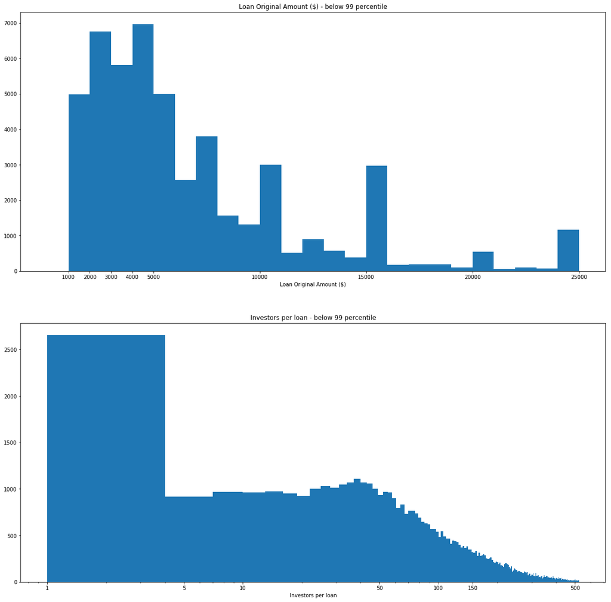

```python
plt.figure(figsize = [20, 20])


loan_select1=loan_1[loan_1['LoanOriginalAmount']<=percentile99l[0]]
loan_select2=loan_1[loan_1['Investors']<=percentile99i[0]]
# histogram on top
plt.subplot(2, 1, 1)
bins = np.arange(0, loan_select1['LoanOriginalAmount'].max()+1000, 1000)
plt.hist(data = loan_select1, x = 'LoanOriginalAmount', bins = bins)
plt.xticks([1000, 2000, 3000, 4000, 5000, 10000, 15000, 20000, 25000],[1000, 2000, 3000, 4000, 5000, 10000, 15000, 20000, 25000]);
plt.xlabel('Loan Original Amount ($)')
plt.title('Loan Original Amount ($) - below 99 percentile')

# histogram on bottom
plt.subplot(2, 1, 2) # 2 rows, 1 col, subplot 2
bins = np.arange(loan_select2['Investors'].min(), loan_select2['Investors'].max()+3, 3)
plt.hist(data = loan_select2, x = 'Investors', bins = bins)
plt.xscale('log')
plt.xticks([1, 5, 10, 50, 100, 150, 500],[1, 5, 10, 50, 100, 150, 500])
plt.xlabel('Investors per loan')
plt.title('Investors per loan - below 99 percentile');
```

```python
loan_1['LoanOriginalAmount'].describe()
```

```
count    49731.000000
mean      6524.492590
std       5269.590049
min       1000.000000
25%       3000.000000
50%       5000.000000
75%       8500.000000
max      35000.000000
Name: LoanOriginalAmount, dtype: float64
```

Looking at the first histogram, we can see that there are peaks of Loan Original Amount around round amounts ( 2000USD, 4000USD, 5000USD, 10000USD). 75% of loans were below 9000 USD.

### Discuss the distribution(s) of your variable(s) of interest. Were there any unusual points? Did you need to perform any transformations?

LOAN-STATUS

Not surprisingly, the majority of the loans are completed. Nevertheless, the summed amount of Defaulted and Chargedoff loans is about 15000, i.e. over 40% of the amount of succesfully completed loans.

Most of loans with past-due payments fall into the category of the shortest delay (1-15 days, 800 observations).

BORROWERAPR

The plot shows a multimodal distribution, with a high peak at 0.355/0.36 interest rate.

I didn't need to transform the data for these two features but I had to do it for RevolvingCreditBalance because the distribution was very skewed to the right. I used a log scale.

### Of the features you investigated, were there any unusual distributions? Did you perform any operations on the data to tidy, adjust, or change the form of the data? If so, why did you do this?

Some of the investigated features showed very right skewed distributions with very extreme outliers. For StatedMonthlyIncome I had to use a limit of x values to be able to visualize distributions. For RevolvingCreditBalance I used the x limit and on top of that the log scale for x values to see if the log distribution was close to normal distribution.

On the other hand, the ListingCreationDate distribution showed an absence of loans for some months as well as a slowing down on the number of loans from July 2009 onwards.

I did some tidying up. First I filtered only the variables that seem interesting for my analysis. Then I dropped null values and duplicates. I changed the format of some variables (date-time variable, categorical data either ordinal or nominal) so I could visualize and manage it without issue. I also filtered out the loans whose LoanStatus was Current or Cancelled because I can't say if they are successful or not (Current means there are instalments to be paid and Cancelled that the loan wasn't given to the borrower).

## Bivariate Exploration

I will first try to see any correlation trends in a scatter matrix of numerical values. I will use a small sample (500 observations) of data to avoid overplotting:

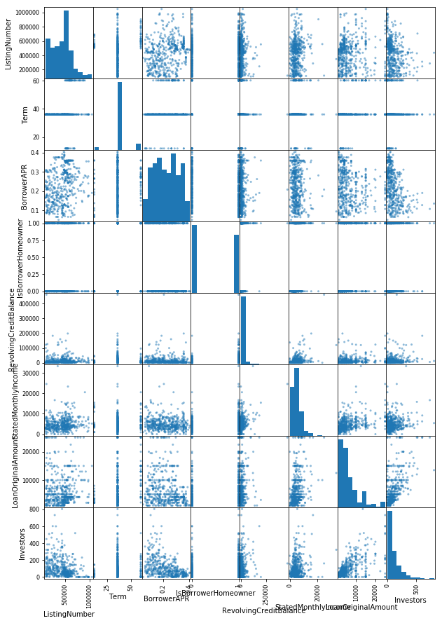

```python
loan_samp=loan_1.sample(n=500, replace=False)
pd.plotting.scatter_matrix(loan_samp, figsize=(10,15));
```

There is no clear correlation between the figures besides between the LoanOriginalAmount and number of Investors. Between those categories there seems to be a positive correlation.

I'd like to see if a Heatmap throws clearer correlation trends.

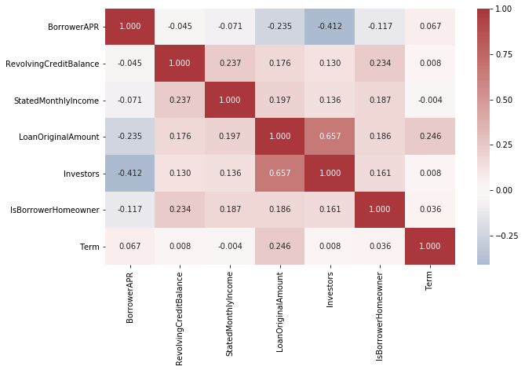

```python
numeric_vars = ['BorrowerAPR', 'RevolvingCreditBalance', 'StatedMonthlyIncome', 'LoanOriginalAmount', 'Investors', 'IsBorrowerHomeowner', 'Term']
categoric_vars = [ 'LoanStatus']

plt.figure(figsize = [10, 6])
sb.heatmap(loan_1[numeric_vars].corr(), annot = True, fmt = '.3f',
           cmap = 'vlag', center = 0)
plt.show();
```

As seen in the scatterplot matrix, the only two variables that seem to have some positive correlation are 'Investors' and 'LoanOriginalAmount'.

#### BorrowerAPR vs LoanStatus

Let's see if BorrowerAPR has some correlation with the LoanStatus. My question is: did 'unsuccesfull' loans (Defaulted, ChargedOff and longer than 120 days past due) have a higher BorrowerAPR which would make it more difficult to reimburse them?

First, I will divide LoanStatus values between 'Succesful' and 'Unsuccesful'.

```python
loan_2=loan_1.replace(['Defaulted', 'Chargedoff','Past Due (>120 days)'], 'Unsuccessful')
loan_2=loan_2.replace(['FinalPaymentInProgress', 'Completed'], 'Successful')
```

```python
values=['Successful','Unsuccessful']
loan_3= loan_2.loc[loan_2['LoanStatus'].isin(values)]
```

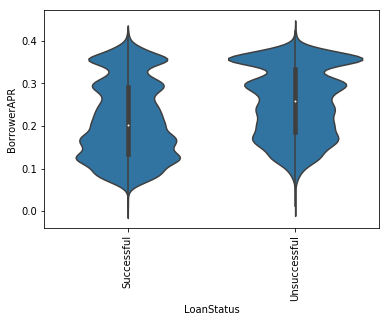

```python
base_color=sb.color_palette()[0]
sb.violinplot(data=loan_3, x='LoanStatus', y='BorrowerAPR',
              color=base_color)
plt.xticks(rotation=90);
```

As for the violinplot above, we can see that there is a trend. The average BorrowerAPR for successful loans is lower than for unsuccesful loans.

Moreover, the first quartile of succesful loans (FinalPaymentInProgress and Completed) is lower than that of unsucessful loans.

It is easily noticeable alse the 'chapeau' on the top of the group of Unsuccesful loans, meaning a concentration of loans around the peak BorrowerAPR seen at BorrowerAPR distribution, i.e. around 35.5% - 36%

#### LoanStatus vs. other features

I'm going to plot the LoanStatus against the numeric variables to see if there is any correlation between LoanStatus and any of them.

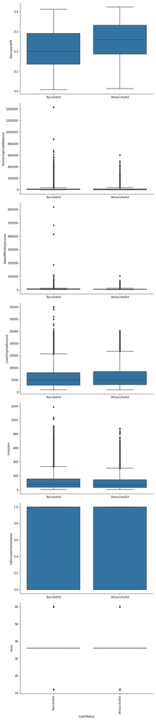

```python
def boxgrid(x, y, **kwargs):
    default_color = sb.color_palette()[0]
    sb.boxplot(x=x, y=y, color=default_color)

plt.figure(figsize = [10, 10])
g = sb.PairGrid(data = loan_3, y_vars = numeric_vars,
                x_vars = 'LoanStatus', size = 5, aspect = 1.5);
g.map(boxgrid)
plt.xticks(rotation=90)
plt.show();
```

The above visualizations seem to indicate that there is not much correlation between any of the numeric variables and LoanStatus. Nevertheless, as the plots are not very easy to interpret due to outliers, I'm going to visualize further some of the variables using other plots.

#### RevolvingCreditBalance vs. LoanStatus

I'd like to know if there is any correlation between the amount of RevolvingCreditBalance and the result of the loans (LoanStatus variable), i.e. do borrowers with a greater revolving credit balance pay back the loans less often than others?

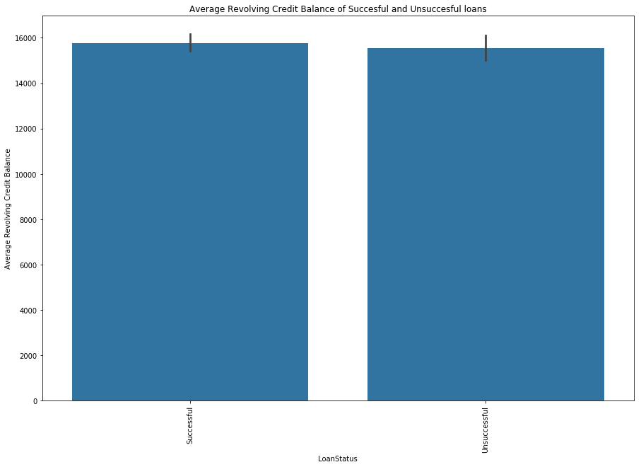

```python
base_color=sb.color_palette()[0]
plt.figure(figsize = [15, 10])
sb.barplot(data=loan_3, x='LoanStatus', y='RevolvingCreditBalance',
           color=base_color)
plt.xticks(rotation=90)
plt.ylabel('Average Revolving Credit Balance')
plt.title('Average Revolving Credit Balance of Succesful and Unsuccesful loans');
```

As we can observe in the figure above, there is no correlation between both variables. Unsuccessful loans (Defaulted, Chargedoff) and successful ones got a similar average revolving credit balance.

#### StatedMonthlyIncome vs. LoanStatus

I'd like to know if having a bigger monthly income has some correlation with completing the payment of the loan by the borrowers.

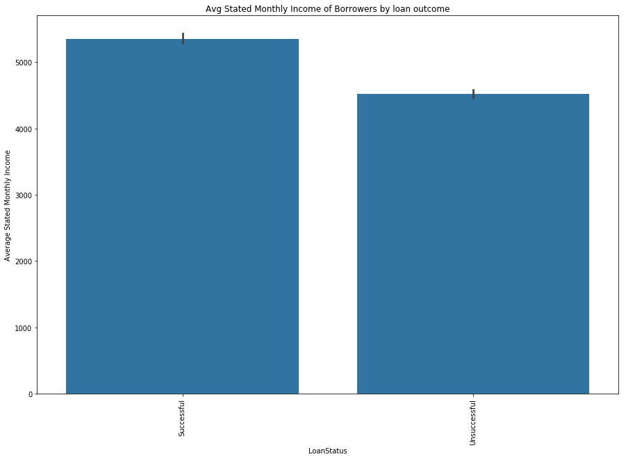

```python
base_color=sb.color_palette()[0]
plt.figure(figsize = [15, 10])
sb.barplot(data=loan_3, x='LoanStatus', y='StatedMonthlyIncome',
           color=base_color)
plt.xticks(rotation=90)
plt.ylabel('Average Stated Monthly Income')
plt.title('Avg Stated Monthly Income of Borrowers by loan outcome');
```

It seems that there is indeed some correlation and the average stated monthly income for successful loans (either completed or final payment in progress) is higher than that of borrowers of Defaulted, Chargedoff or 'Past due (>120days)' loans.

#### ListingCreationDate vs. LoanStatus

I wonder if changing the rules for obtaining loans after July 2009 could have some correlation with the amount of loans that were not succesful.

I will select the unsuccesful loans only (Defaulted, ChargedOff, Past Due (>120 days)), visualize them over time while comparing them to the full sample of loans with all the different loan status in it.

```python
# I create a dataframe with only unsuccesful loans
values=['Defaulted','Chargedoff','Past Due (>120 days)']
loan_date2= loan_date.loc[loan_date['LoanStatus'].isin(values)]
```

Now I'm going to set date as index.

```python
loan_date.set_index('ListingCreationDate', inplace=True)
loan_date2.set_index('ListingCreationDate', inplace=True)
```

I check whether it worked or not

```python
loan_date2.head()
```

| ListingCreationDate | ListingNumber | Term | LoanStatus | BorrowerAPR | EmploymentStatus | IsBorrowerHomeowner | RevolvingCreditBalance | StatedMonthlyIncome | LoanOriginalAmount | Investors | ListingCreationMonth |
| --- | --- | --- | --- | --- | --- | --- | --- | --- | --- | --- | --- |
| 2007-02-12 | 98331 | 36 | Defaulted | 0.27535 | Employed | False | 0.0 | 2442.416667 | 2000 | 14 | 2007-02 |
| 2007-02-24 | 103060 | 36 | Chargedoff | 0.21739 | Employed | True | 246710.0 | 0.083333 | 5000 | 128 | 2007-02 |
| 2007-02-14 | 99682 | 36 | Chargedoff | 0.14699 | Employed | True | 32151.0 | 6833.333333 | 10000 | 278 | 2007-02 |
| 2007-02-20 | 101669 | 36 | Chargedoff | 0.25948 | Employed | True | 0.0 | 433.333333 | 2000 | 26 | 2007-02 |
| 2007-02-27 | 104304 | 36 | Chargedoff | 0.18214 | Employed | True | 0.0 | 5870.916667 | 15000 | 400 | 2007-02 |

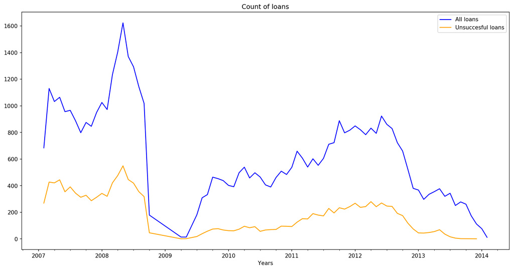

```python
# to set the plot size
plt.figure(figsize=(16, 8), dpi=150)


# in plot method we set the label and color of the curve.
loan_date.groupby('ListingCreationMonth').count()['LoanStatus'].plot(label='All loans', color='blue')
loan_date2.groupby('ListingCreationMonth').count()['LoanStatus'].plot(label='Unsuccesful loans', color='orange');


# adding title to the plot
plt.title('Count of loans')

# adding Label to the x-axis
plt.xlabel('Years')

# adding legend to the curve
plt.legend()
```

In the visualization above we can observe over time the amount of all sample loans (in blue) and the unsuccessful loans (in yellow). Before the visualization I was wondering whether stricter rules to get a loan after July 2009 would have an impact on the count of unsuccessful loans. As per the visualization above, it seems it slightly did.

#### EmploymentStatus vs. Loan Status

I wonder if borrowers with a job or employed achieved to pay back loans more often in average than those in other categories.

I'm going to use a clurstered bar chart to compare the two categorical variables

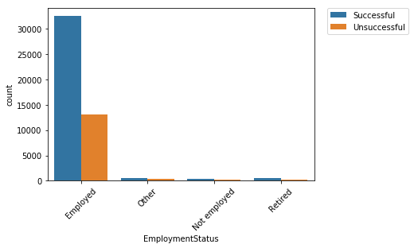

```python
sb.countplot(data=loan_3, x='EmploymentStatus', hue='LoanStatus')
plt.xticks(rotation=45)
plt.legend(bbox_to_anchor=(1.05, 1), loc=2, borderaxespad=0.);
```

I need to work with proportions to see whether there is a correlation between the loan status and the employment status. Otherwise, the total values of Employed category and Completed category make the visualization difficult to understand.

```python
counts=loan_3.groupby(['LoanStatus','EmploymentStatus']).count()['Term']
totals=loan_3.groupby('EmploymentStatus').count()['Term']
proportions=counts/totals
```

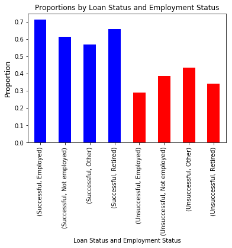

```python
my_colors = ['blue','blue','blue','blue','red','red','red','red']
proportions.plot(kind='bar', title="Proportions by Loan Status and Employment Status", color=my_colors)
plt.xlabel('Loan Status and Employment Status')

plt.ylabel('Proportion', fontsize=12);
```

#### Homeowner vs. LoanStatus

I would like to know if there is some positive correlation between not being homeowner and not reimboursing a loan

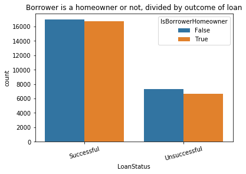

```python
sb.countplot(data=loan_3, x='LoanStatus', hue='IsBorrowerHomeowner')
plt.xticks(rotation=15)
plt.title('Borrower is a homeowner or not, divided by outcome of loan');
```

As we can see above, the proportion of borrowers that do not own a house is bigger for the unsuccesful loans. Nevetheless, in both groups (succesful and unsuccessful loans) the majority of borrowers are not home owners and the gap between owners and not owners is not very significant in either group. There is no correlation between being a homeowner and succesfully paying back the loan.

#### BorrowerAPR over time

I wonder if external factors as interest rates for loans in national finantial markets/banks or economic crisis of 2008 could have some influence on the evolution of average Borrower APR over time

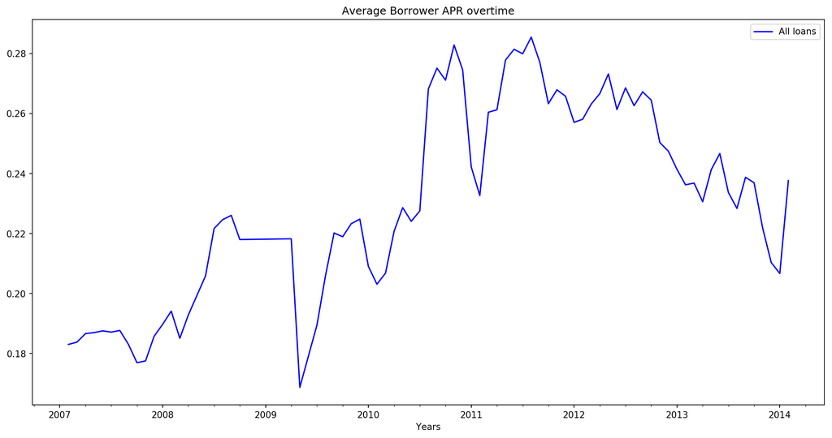

```python
# to set the plot size
plt.figure(figsize=(16, 8), dpi=150)


# in plot method we set the label and color of the curve.
loan_date.groupby('ListingCreationMonth')['BorrowerAPR'].mean().plot(label='All loans', color='blue');


# adding title to the plot
plt.title('Average Borrower APR overtime');

# adding Label to the x-axis
plt.xlabel('Years');

# adding legend to the curve
plt.legend();
```

As we can observe above, the average Borrower APR has stayed between 0.18 and 0.28 between 2007 and 2014. Nevertheless, it has varied quite a lot between those two values over the time. It could be related to the evolution of interest rates in the financial market or due to the characteristics of the borrowers and lenders of Prosper loans at that very moment. Finding out the reason of the variation is beyond the scope of our analysis.

Note: The very low deep in 2009 represents the temporary suspension of activity due to SEC's intervention.

#### BorrowerAPR vs. EmploymentStatus

In despite of BorrowerAPR being maybe affected by interest rates in financial markets others than Prosper company itself, I'm thinking there might be other features it could have some correlation with. For example, I wonder if having a job at the moment of the loan request, the obtained borrower APR could be lower.

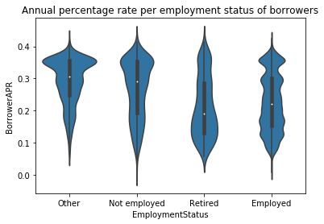

```python
base_color=sb.color_palette()[0]

sb.violinplot(data=loan_1, x='EmploymentStatus', y='BorrowerAPR', size=8,
              color=base_color)
plt.xticks()
plt.title('Annual percentage rate per employment status of borrowers');
```

As we can see in the visualization above, the retired borrowers got in average the lowest BorrowerAPR. The least favorable or highest BorrowerAPR were for the loans of borrowers whose employment status was 'other'. Moreover, at the top of the figure for 'other' status, we can see a concentration of observations around the 0.35 borrower apr, in the high end of the interest rate range. Therefore, it seems there is some correlation between having a steady income (either due to a job or retirement income) and getting a low annual interest rate.

### Talk about some of the relationships you observed in this part of the investigation. How did the feature(s) of interest vary with other features in the dataset?

BorrowerAPR doesn't seem to have any correlation with most of the analysed features. It has some negative correlation with the employment status, being employed and retired status borrowers the ones getting the lowest APR in average. Also it has some negative correlation with the other feature of interest, LoanStatus. Indeed, loans classed as successful (Completed and last payment in process) have an average lower BorrowerAPR than the rest. BorrowerAPR has also varied quite over time. We can't exclude external factors (cost of money, interest rate in financial markets, economic crisis in 2008) being part of the reason.

I observed some positive correlation between StatedMonthlyIncome and LoanStatus, i.e. borrowers of successful loans stated a higher monthly income than those of unsuccesful loans.

There is also some correlation between the loan status and the employment status. Borrowers that declared to be employed pay the totality of the loan more often (70% of the time in the sample) than borrowers with other employment status.

### Did you observe any interesting relationships between the other features (not the main feature(s) of interest)?

There is positive correlation between LoanOriginalAmount and Investors, meaning that bigger loans get in average more investors to finance them.

## Multivariate Exploration

#### BorrowerAPR vs. LoanStatus vs. EmploymentStatus

The correlation between these three figures has been established in bivariate visualizations in different combinations. I'd like to see if a multivariate visualization of the three of them shows any new information.

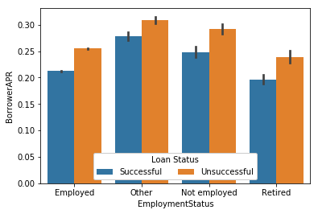

```python
#I'm using an adaptation of a barplot
ax= sb.barplot(data=loan_3, x='EmploymentStatus', y='BorrowerAPR',
               hue='LoanStatus')
ax.legend(loc=8, ncol=3, framealpha=1, title='Loan Status');
```

We can see the correlation between the three variables. Besides we can see a new relationship. Indeed, we knew that Other employment status and Not Employed borrowers got a higher interest rate in average than Retired and Employed borrowers. Similarly unsuccesful loans got in average a higher borrower apr than succesful ones. Now, we can see that succesful loans for the unemployed and 'other' employment status borrowers got a similar average interest rate than unsuccesful loans of employed and retired borrowers. In other words, the employment status of borrowers seem to factor quite heavily in the interest rate granted for the loans.

#### BorrowerAPR vs. Loan Original Amount vs. Loan Status

I'd like to see if there is some correlation between the two features of interest (BorrowerAPR and LoanStatus) and the LoanOriginalAmount, i.e. do loans of bigger amount get a higher BorrowerAPR or/and are more often unsuccesful?

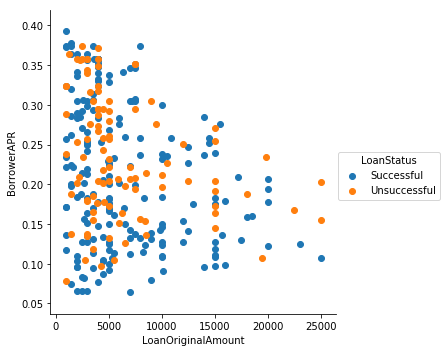

```python
loan_samp3=loan_3.sample(n=300, replace=False)
g=sb.FacetGrid(data=loan_samp3, hue='LoanStatus', size=5)
g.map(plt.scatter, 'LoanOriginalAmount', 'BorrowerAPR')
g.add_legend();
```

As per the visualization, it seems that most loans are mainly below 15000USD and unsuccesful loans have in average a higher BorrowerAPR than succesful loans. On the other hand, my null hypothesis (bigger loans are more prone to be unsuccessful and get a higher interest rate) can't be accepted. Indeed, the ratio of unsuccesful/succesful loans might increase as it does the LoanOriginalAmount, but bigger amount loans have in average a lower BorroweAPR as per our visualization.

#### Loan Original Amount vs. Investors vs. LoanStatus

There is some positive correlation between Loan Original Amount and number of investors. I'm wondering if the loans of a bigger original amount and many investors are successful more often than smaller loans and with less investors.

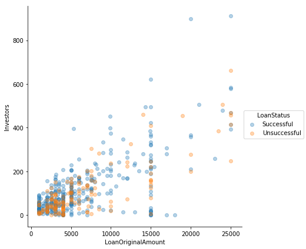

```python
loan_samp3=loan_3.sample(n=500, replace=False)
g=sb.FacetGrid(data=loan_samp3, hue='LoanStatus', size=6)
g.map(plt.scatter, 'LoanOriginalAmount', 'Investors', alpha=1/3)
g.add_legend();
```

The positive correlation between the number of investors and the original amount of the loan can be seen in the visualization above. Bigger loans get often more investors. As for the loan status, there are successful and unsuccessful loans for any original amount of the loan. Nevertheless, the ratio unsuccesful/succesful loans seems to increase as the loan original amount does, too. On the other hand, there seems to be no clear correlation between the number of investors and the loan status.

### Were there any interesting or surprising interactions between features?

Surprisingly loans with a bigger original amount got in average a lower BorrowerAPR than small loans

## Conclusions

I started by cleaning and tidying up the dataset by dropping null values, duplicates and modifying the format of some features.

I chose the two features that interested me most : LoanStatus and BorrowerAPR (annual interest rate of the loans). I thought about which features could have some correlation with my two features of interest : 'stated monthly income', 'employment status' and the 'revolving credit balance'.

Then I started the exploratory analysis by univariate visualization. The most interesting findings at that level were that:

- over 28% of loans in the sample were not paid back, i.e. the risk for lenders is quite high as compared to other financial products.
- BorrowerAPR, or annual interest rate had a peak at 0.355-0.36, which is a very high interest rate for a loan.
- Count of loans decreased and even stopped during a few months between October 2008 and May 2009. The reason was SEC's intervention. Since then the rules to grant loans got more strict. Therefore the count of loans from July 2009 onwards decreased and didn't get back to previous level. The ratio between Unsuccessful (not paid back to lenders) and Succesful (paid back) also decreased.
- Majority of borrowers were employed, either by a company or self-employed
- A few numerical features were really skewed to the right: RevolvingCreditBalance, StatedMonthlyIncome and LoanOriginalAmount. I had to limit the range of values to visualize them and sometimes I used a log scale, too.

During the bivariate visualizations, I started doing a correlation matrix between BorrowerAPR and numerical features (Term, IsBorrowerHomeowner, Investors, LoanOriginalAmount, RevolvingCreditBalance and StatedMonthlyIncome). I found no correlation between most of them and BorrowerAPR or LoanStatus feature. Nevertheless, I found out that :

- There is quite a strong negative correlation between the two features of interest, i.e. LoanStatus and BorrowerAPR. Succesful loans got over all a lower average BorrowerAPR.
- There is some positive correlation between LoanStatus and LoanOriginal Amount: there are proportionally more loans with a bigger amount among unsuccessful loans, eventhough average loan amount for either succesful and unsuccesful loans is very similar.
- There is some positive correlation between StatedMonthlyIncome and LoanStatus. Borrowers of successful loans stated in average about 1000USD of monthly income more (about 5500USD) than those of unsuccesful loans (4500USD).
- There is some correlation between Employed and Retired values of EmploymentStatus and LoanStatus. Indeed, borrowers from these two categories were proportionnaly more succesful paying back the loans than borrowers in categories Unemployed and Other.
- Similarly,employed or retired borrowers got a lower average annual interest rate (BorrowerAPR) than the other two categories.

I wanted to see another side of the borrowerAPR vs. loanstatus correlation by adding LoanOriginalAmount in a multivariate visualization. I could observe that:

- Most loans original amount is below 15000USD.
- The ratio between unsuccesful and succesful loans increases as the loan original amount does, but the BorrowerAPR is in average lower when the loan original amount increases. This means that unsuccesful loans concentrate around small loan original amounts at a higher average APR rate than succesful loans

I also visualized investors against loan original amount and loan status to deepen in the correlation between investors and loan original amount:

- The positive correlation between these two figures was easy to identify in the visualization.
- As for the loan status, there seemed to be an increasing ratio of unsuccesful/succesful loans as the amount of the loan increased. Nevertheless, there seemed to be no correlation between the number of investors and the loan status.